# Risk Factor Analysis

## Outcome Variable

**Outcome Variable:** ever_wasted

## Predictor Variables

**Intervention Variable:** hfoodsec

**Adjustment Set:**

- arm
- sex
- W_mage
- meducyrs
- feducyrs
- hhwealth_quart
- vagbrth
- W_nrooms
- W_nchldlt5
- brthmon
- W_parity
- impfloor
- impsan
- safeh20
- delta_W_mage
- delta_meducyrs
- delta_feducyrs
- delta_hhwealth_quart
- delta_vagbrth
- delta_W_nrooms
- delta_W_nchldlt5
- delta_brthmon
- delta_W_parity
- delta_impfloor
- delta_impsan
- delta_safeh20

## Stratifying Variables

The analysis was stratified on these variable(s):

- agecat
- studyid
- country

## Data Summary

| agecat | studyid | country | hfoodsec | ever_wasted | n_cell | n |
| --- | --- | --- | --- | --- | --- | --- |
| 0-24 months | GMS-Nepal | NEPAL | Food Secure | 0 | 188 | 663 |
| 0-24 months | GMS-Nepal | NEPAL | Food Secure | 1 | 283 | 663 |
| 0-24 months | GMS-Nepal | NEPAL | Mildly Food Insecure | 0 | 55 | 663 |
| 0-24 months | GMS-Nepal | NEPAL | Mildly Food Insecure | 1 | 50 | 663 |
| 0-24 months | GMS-Nepal | NEPAL | Food Insecure | 0 | 28 | 663 |
| 0-24 months | GMS-Nepal | NEPAL | Food Insecure | 1 | 59 | 663 |
| 0-24 months | JiVitA-3 | BANGLADESH | Food Secure | 0 | 6332 | 17375 |
| 0-24 months | JiVitA-3 | BANGLADESH | Food Secure | 1 | 2364 | 17375 |
| 0-24 months | JiVitA-3 | BANGLADESH | Mildly Food Insecure | 0 | 4087 | 17375 |
| 0-24 months | JiVitA-3 | BANGLADESH | Mildly Food Insecure | 1 | 1697 | 17375 |
| 0-24 months | JiVitA-3 | BANGLADESH | Food Insecure | 0 | 1924 | 17375 |
| 0-24 months | JiVitA-3 | BANGLADESH | Food Insecure | 1 | 971 | 17375 |
| 0-24 months | JiVitA-4 | BANGLADESH | Food Secure | 0 | 1896 | 5399 |
| 0-24 months | JiVitA-4 | BANGLADESH | Food Secure | 1 | 853 | 5399 |
| 0-24 months | JiVitA-4 | BANGLADESH | Mildly Food Insecure | 0 | 1333 | 5399 |
| 0-24 months | JiVitA-4 | BANGLADESH | Mildly Food Insecure | 1 | 615 | 5399 |
| 0-24 months | JiVitA-4 | BANGLADESH | Food Insecure | 0 | 494 | 5399 |
| 0-24 months | JiVitA-4 | BANGLADESH | Food Insecure | 1 | 208 | 5399 |
| 0-24 months | MAL-ED | BANGLADESH | Food Secure | 0 | 105 | 194 |
| 0-24 months | MAL-ED | BANGLADESH | Food Secure | 1 | 56 | 194 |
| 0-24 months | MAL-ED | BANGLADESH | Mildly Food Insecure | 0 | 3 | 194 |
| 0-24 months | MAL-ED | BANGLADESH | Mildly Food Insecure | 1 | 1 | 194 |
| 0-24 months | MAL-ED | BANGLADESH | Food Insecure | 0 | 19 | 194 |
| 0-24 months | MAL-ED | BANGLADESH | Food Insecure | 1 | 10 | 194 |
| 0-24 months | MAL-ED | BRAZIL | Food Secure | 0 | 3 | 129 |
| 0-24 months | MAL-ED | BRAZIL | Food Secure | 1 | 0 | 129 |
| 0-24 months | MAL-ED | BRAZIL | Mildly Food Insecure | 0 | 11 | 129 |
| 0-24 months | MAL-ED | BRAZIL | Mildly Food Insecure | 1 | 0 | 129 |
| 0-24 months | MAL-ED | BRAZIL | Food Insecure | 0 | 103 | 129 |
| 0-24 months | MAL-ED | BRAZIL | Food Insecure | 1 | 12 | 129 |

[output cut: 168 more lines]

The following strata were considered:

- agecat: 0-24 months, studyid: GMS-Nepal, country: NEPAL
- agecat: 0-24 months, studyid: JiVitA-3, country: BANGLADESH
- agecat: 0-24 months, studyid: JiVitA-4, country: BANGLADESH
- agecat: 0-24 months, studyid: MAL-ED, country: BANGLADESH
- agecat: 0-24 months, studyid: MAL-ED, country: BRAZIL
- agecat: 0-24 months, studyid: MAL-ED, country: INDIA
- agecat: 0-24 months, studyid: MAL-ED, country: NEPAL
- agecat: 0-24 months, studyid: MAL-ED, country: PERU
- agecat: 0-24 months, studyid: MAL-ED, country: SOUTH AFRICA
- agecat: 0-24 months, studyid: NIH-Birth, country: BANGLADESH
- agecat: 0-24 months, studyid: NIH-Crypto, country: BANGLADESH
- agecat: 0-6 months, studyid: GMS-Nepal, country: NEPAL
- agecat: 0-6 months, studyid: JiVitA-3, country: BANGLADESH
- agecat: 0-6 months, studyid: JiVitA-4, country: BANGLADESH
- agecat: 0-6 months, studyid: MAL-ED, country: BANGLADESH
- agecat: 0-6 months, studyid: MAL-ED, country: BRAZIL
- agecat: 0-6 months, studyid: MAL-ED, country: INDIA
- agecat: 0-6 months, studyid: MAL-ED, country: NEPAL
- agecat: 0-6 months, studyid: MAL-ED, country: PERU
- agecat: 0-6 months, studyid: MAL-ED, country: SOUTH AFRICA
- agecat: 0-6 months, studyid: NIH-Birth, country: BANGLADESH
- agecat: 0-6 months, studyid: NIH-Crypto, country: BANGLADESH
- agecat: 6-24 months, studyid: GMS-Nepal, country: NEPAL
- agecat: 6-24 months, studyid: JiVitA-3, country: BANGLADESH
- agecat: 6-24 months, studyid: JiVitA-4, country: BANGLADESH
- agecat: 6-24 months, studyid: MAL-ED, country: BANGLADESH
- agecat: 6-24 months, studyid: MAL-ED, country: BRAZIL
- agecat: 6-24 months, studyid: MAL-ED, country: INDIA
- agecat: 6-24 months, studyid: MAL-ED, country: NEPAL
- agecat: 6-24 months, studyid: MAL-ED, country: PERU
- agecat: 6-24 months, studyid: MAL-ED, country: SOUTH AFRICA
- agecat: 6-24 months, studyid: NIH-Birth, country: BANGLADESH
- agecat: 6-24 months, studyid: NIH-Crypto, country: BANGLADESH

### Dropped Strata

Some strata were dropped due to rare outcomes:

- agecat: 0-24 months, studyid: MAL-ED, country: BANGLADESH
- agecat: 0-24 months, studyid: MAL-ED, country: BRAZIL
- agecat: 0-24 months, studyid: MAL-ED, country: INDIA
- agecat: 0-24 months, studyid: MAL-ED, country: PERU
- agecat: 0-24 months, studyid: MAL-ED, country: SOUTH AFRICA
- agecat: 0-6 months, studyid: MAL-ED, country: BANGLADESH
- agecat: 0-6 months, studyid: MAL-ED, country: BRAZIL
- agecat: 0-6 months, studyid: MAL-ED, country: INDIA
- agecat: 0-6 months, studyid: MAL-ED, country: NEPAL
- agecat: 0-6 months, studyid: MAL-ED, country: PERU
- agecat: 0-6 months, studyid: MAL-ED, country: SOUTH AFRICA
- agecat: 6-24 months, studyid: MAL-ED, country: BANGLADESH
- agecat: 6-24 months, studyid: MAL-ED, country: BRAZIL
- agecat: 6-24 months, studyid: MAL-ED, country: INDIA
- agecat: 6-24 months, studyid: MAL-ED, country: NEPAL
- agecat: 6-24 months, studyid: MAL-ED, country: PERU
- agecat: 6-24 months, studyid: MAL-ED, country: SOUTH AFRICA

## Methods Detail

We’re interested in the causal parameters $E[Y_a]$ for all values of $a \in \mathcal{A}$. These parameters represent the mean outcome if, possibly contrary to fact, we intervened to set all units to have $A=a$. Under the randomization and positivity assumptions, these are identified by the statistical parameters $\psi_a=E_W[E_{Y|A,W}(Y|A=a,W)]$. In addition, we’re interested in the mean of $Y$, $E[Y]$ under no intervention (the observed mean). We will estimate these parameters by using SuperLearner to fit the relevant likelihood factors – $E_{Y|A,W}(Y|A=a,W)$ and $p(A=a|W)$, and then updating our likelihood fit using a joint TMLE.

For unadjusted analyses ($W=\{\}$), initial likelihoods were estimated using Lrnr_glm to estimate the simple $E(Y|A)$ and Lrnr_mean to estimate $p(A)$. For adjusted analyses, a small library containing Lrnr_glmnet, Lrnr_xgboost, and Lrnr_mean was used.

Having estimated these parameters, we will then use the delta method to estimate relative risks and attributable risks relative to a prespecified baseline level of $A$.

# Results Detail

## Results Plots

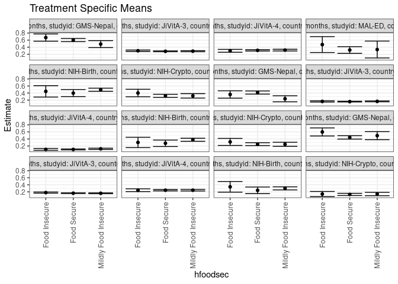

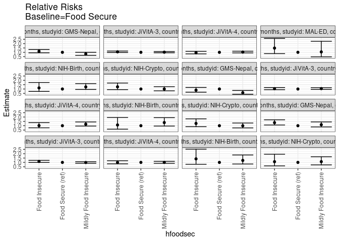

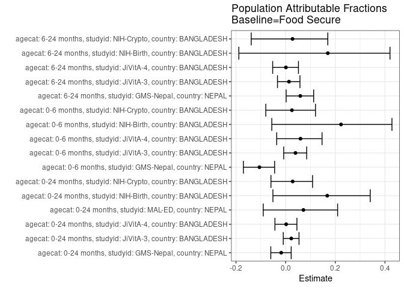

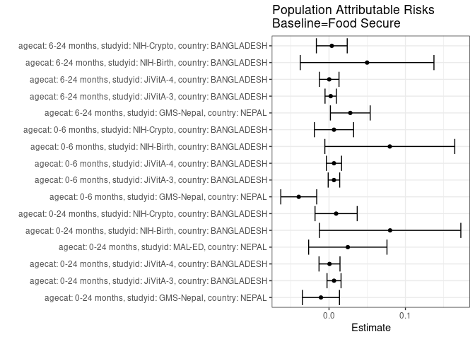

## Results Table

### Parameter: TSM

| agecat | studyid | country | intervention_level | baseline_level | estimate | ci_lower | ci_upper |
| --- | --- | --- | --- | --- | --- | --- | --- |
| 0-24 months | GMS-Nepal | NEPAL | Food Secure | NA | 0.6018193 | 0.5573820 | 0.6462565 |
| 0-24 months | GMS-Nepal | NEPAL | Mildly Food Insecure | NA | 0.4869044 | 0.3879630 | 0.5858457 |
| 0-24 months | GMS-Nepal | NEPAL | Food Insecure | NA | 0.6721733 | 0.5699474 | 0.7743991 |
| 0-24 months | JiVitA-3 | BANGLADESH | Food Secure | NA | 0.2830368 | 0.2709074 | 0.2951662 |
| 0-24 months | JiVitA-3 | BANGLADESH | Mildly Food Insecure | NA | 0.2867219 | 0.2714841 | 0.3019598 |
| 0-24 months | JiVitA-3 | BANGLADESH | Food Insecure | NA | 0.2983341 | 0.2771305 | 0.3195377 |
| 0-24 months | JiVitA-4 | BANGLADESH | Food Secure | NA | 0.3097746 | 0.2899523 | 0.3295969 |
| 0-24 months | JiVitA-4 | BANGLADESH | Mildly Food Insecure | NA | 0.3167005 | 0.2927320 | 0.3406691 |
| 0-24 months | JiVitA-4 | BANGLADESH | Food Insecure | NA | 0.2966869 | 0.2557191 | 0.3376547 |
| 0-24 months | MAL-ED | NEPAL | Food Secure | NA | 0.3191489 | 0.2245448 | 0.4137531 |
| 0-24 months | MAL-ED | NEPAL | Mildly Food Insecure | NA | 0.3333333 | 0.0938367 | 0.5728299 |
| 0-24 months | MAL-ED | NEPAL | Food Insecure | NA | 0.4736842 | 0.2482904 | 0.6990781 |
| 0-24 months | NIH-Birth | BANGLADESH | Food Secure | NA | 0.3976121 | 0.2975373 | 0.4976869 |
| 0-24 months | NIH-Birth | BANGLADESH | Mildly Food Insecure | NA | 0.4937805 | 0.4493503 | 0.5382107 |
| 0-24 months | NIH-Birth | BANGLADESH | Food Insecure | NA | 0.4477968 | 0.2863502 | 0.6092434 |
| 0-24 months | NIH-Crypto | BANGLADESH | Food Secure | NA | 0.3205066 | 0.2774504 | 0.3635628 |
| 0-24 months | NIH-Crypto | BANGLADESH | Mildly Food Insecure | NA | 0.3203749 | 0.2584354 | 0.3823144 |
| 0-24 months | NIH-Crypto | BANGLADESH | Food Insecure | NA | 0.4011874 | 0.2943528 | 0.5080220 |
| 0-6 months | GMS-Nepal | NEPAL | Food Secure | NA | 0.4151694 | 0.3703362 | 0.4600025 |
| 0-6 months | GMS-Nepal | NEPAL | Mildly Food Insecure | NA | 0.2376378 | 0.1520130 | 0.3232626 |
| 0-6 months | GMS-Nepal | NEPAL | Food Insecure | NA | 0.3595025 | 0.2559582 | 0.4630468 |
| 0-6 months | JiVitA-3 | BANGLADESH | Food Secure | NA | 0.1565610 | 0.1466462 | 0.1664758 |
| 0-6 months | JiVitA-3 | BANGLADESH | Mildly Food Insecure | NA | 0.1639041 | 0.1520516 | 0.1757566 |
| 0-6 months | JiVitA-3 | BANGLADESH | Food Insecure | NA | 0.1623351 | 0.1452378 | 0.1794325 |
| 0-6 months | JiVitA-4 | BANGLADESH | Food Secure | NA | 0.1020358 | 0.0888378 | 0.1152338 |
| 0-6 months | JiVitA-4 | BANGLADESH | Mildly Food Insecure | NA | 0.1197178 | 0.1017127 | 0.1377230 |
| 0-6 months | JiVitA-4 | BANGLADESH | Food Insecure | NA | 0.1033304 | 0.0767990 | 0.1298618 |
| 0-6 months | NIH-Birth | BANGLADESH | Food Secure | NA | 0.2773376 | 0.1861102 | 0.3685650 |
| 0-6 months | NIH-Birth | BANGLADESH | Mildly Food Insecure | NA | 0.3774079 | 0.3342684 | 0.4205473 |
| 0-6 months | NIH-Birth | BANGLADESH | Food Insecure | NA | 0.3007058 | 0.1550132 | 0.4463983 |
| 0-6 months | NIH-Crypto | BANGLADESH | Food Secure | NA | 0.2507606 | 0.2106923 | 0.2908290 |
| 0-6 months | NIH-Crypto | BANGLADESH | Mildly Food Insecure | NA | 0.2483812 | 0.1909394 | 0.3058229 |
| 0-6 months | NIH-Crypto | BANGLADESH | Food Insecure | NA | 0.3159570 | 0.2166434 | 0.4152706 |
| 6-24 months | GMS-Nepal | NEPAL | Food Secure | NA | 0.4433517 | 0.3950420 | 0.4916614 |
| 6-24 months | GMS-Nepal | NEPAL | Mildly Food Insecure | NA | 0.4932068 | 0.3789966 | 0.6074171 |
| 6-24 months | GMS-Nepal | NEPAL | Food Insecure | NA | 0.5979414 | 0.4840317 | 0.7118511 |
| 6-24 months | JiVitA-3 | BANGLADESH | Food Secure | NA | 0.1617600 | 0.1522927 | 0.1712273 |
| 6-24 months | JiVitA-3 | BANGLADESH | Mildly Food Insecure | NA | 0.1596262 | 0.1480695 | 0.1711830 |
| 6-24 months | JiVitA-3 | BANGLADESH | Food Insecure | NA | 0.1795147 | 0.1625555 | 0.1964739 |
| 6-24 months | JiVitA-4 | BANGLADESH | Food Secure | NA | 0.2470510 | 0.2281331 | 0.2659689 |
| 6-24 months | JiVitA-4 | BANGLADESH | Mildly Food Insecure | NA | 0.2471965 | 0.2252086 | 0.2691845 |
| 6-24 months | JiVitA-4 | BANGLADESH | Food Insecure | NA | 0.2466330 | 0.2073441 | 0.2859220 |
| 6-24 months | NIH-Birth | BANGLADESH | Food Secure | NA | 0.2435144 | 0.1499500 | 0.3370788 |
| 6-24 months | NIH-Birth | BANGLADESH | Mildly Food Insecure | NA | 0.2993908 | 0.2556574 | 0.3431242 |
| 6-24 months | NIH-Birth | BANGLADESH | Food Insecure | NA | 0.3428878 | 0.1921749 | 0.4936008 |
| 6-24 months | NIH-Crypto | BANGLADESH | Food Secure | NA | 0.1278605 | 0.0964850 | 0.1592361 |
| 6-24 months | NIH-Crypto | BANGLADESH | Mildly Food Insecure | NA | 0.1386721 | 0.0912685 | 0.1860757 |
| 6-24 months | NIH-Crypto | BANGLADESH | Food Insecure | NA | 0.1381113 | 0.0645527 | 0.2116698 |

### Parameter: E(Y)

| agecat | studyid | country | intervention_level | baseline_level | estimate | ci_lower | ci_upper |
| --- | --- | --- | --- | --- | --- | --- | --- |
| 0-24 months | GMS-Nepal | NEPAL | NA | NA | 0.5912519 | 0.5538035 | 0.6287003 |
| 0-24 months | JiVitA-3 | BANGLADESH | NA | NA | 0.2896115 | 0.2819717 | 0.2972513 |
| 0-24 months | JiVitA-4 | BANGLADESH | NA | NA | 0.3104279 | 0.2959885 | 0.3248672 |
| 0-24 months | MAL-ED | NEPAL | NA | NA | 0.3437500 | 0.2611458 | 0.4263542 |
| 0-24 months | NIH-Birth | BANGLADESH | NA | NA | 0.4775641 | 0.4383415 | 0.5167867 |
| 0-24 months | NIH-Crypto | BANGLADESH | NA | NA | 0.3298153 | 0.2963239 | 0.3633067 |
| 0-6 months | GMS-Nepal | NEPAL | NA | NA | 0.3755656 | 0.3386759 | 0.4124553 |
| 0-6 months | JiVitA-3 | BANGLADESH | NA | NA | 0.1630114 | 0.1568185 | 0.1692043 |
| 0-6 months | JiVitA-4 | BANGLADESH | NA | NA | 0.1085195 | 0.0986291 | 0.1184098 |
| 0-6 months | NIH-Birth | BANGLADESH | NA | NA | 0.3569132 | 0.3192325 | 0.3945938 |
| 0-6 months | NIH-Crypto | BANGLADESH | NA | NA | 0.2572559 | 0.2261171 | 0.2883948 |
| 6-24 months | GMS-Nepal | NEPAL | NA | NA | 0.4712042 | 0.4302971 | 0.5121113 |
| 6-24 months | JiVitA-3 | BANGLADESH | NA | NA | 0.1639687 | 0.1578505 | 0.1700868 |
| 6-24 months | JiVitA-4 | BANGLADESH | NA | NA | 0.2473078 | 0.2336663 | 0.2609494 |
| 6-24 months | NIH-Birth | BANGLADESH | NA | NA | 0.2933579 | 0.2549918 | 0.3317241 |
| 6-24 months | NIH-Crypto | BANGLADESH | NA | NA | 0.1315068 | 0.1069744 | 0.1560393 |

### Parameter: RR

| agecat | studyid | country | intervention_level | baseline_level | estimate | ci_lower | ci_upper |
| --- | --- | --- | --- | --- | --- | --- | --- |
| 0-24 months | GMS-Nepal | NEPAL | Food Secure | Food Secure | 1.0000000 | 1.0000000 | 1.0000000 |
| 0-24 months | GMS-Nepal | NEPAL | Mildly Food Insecure | Food Secure | 0.8090541 | 0.6517204 | 1.0043702 |
| 0-24 months | GMS-Nepal | NEPAL | Food Insecure | Food Secure | 1.1169022 | 0.9430621 | 1.3227872 |
| 0-24 months | JiVitA-3 | BANGLADESH | Food Secure | Food Secure | 1.0000000 | 1.0000000 | 1.0000000 |
| 0-24 months | JiVitA-3 | BANGLADESH | Mildly Food Insecure | Food Secure | 1.0130199 | 0.9463022 | 1.0844416 |
| 0-24 months | JiVitA-3 | BANGLADESH | Food Insecure | Food Secure | 1.0540470 | 0.9734837 | 1.1412776 |
| 0-24 months | JiVitA-4 | BANGLADESH | Food Secure | Food Secure | 1.0000000 | 1.0000000 | 1.0000000 |
| 0-24 months | JiVitA-4 | BANGLADESH | Mildly Food Insecure | Food Secure | 1.0223580 | 0.9281670 | 1.1261075 |
| 0-24 months | JiVitA-4 | BANGLADESH | Food Insecure | Food Secure | 0.9577510 | 0.8215945 | 1.1164715 |
| 0-24 months | MAL-ED | NEPAL | Food Secure | Food Secure | 1.0000000 | 1.0000000 | 1.0000000 |
| 0-24 months | MAL-ED | NEPAL | Mildly Food Insecure | Food Secure | 1.0444444 | 0.4801047 | 2.2721381 |
| 0-24 months | MAL-ED | NEPAL | Food Insecure | Food Secure | 1.4842105 | 0.8472771 | 2.5999533 |
| 0-24 months | NIH-Birth | BANGLADESH | Food Secure | Food Secure | 1.0000000 | 1.0000000 | 1.0000000 |
| 0-24 months | NIH-Birth | BANGLADESH | Mildly Food Insecure | Food Secure | 1.2418648 | 0.9505656 | 1.6224322 |
| 0-24 months | NIH-Birth | BANGLADESH | Food Insecure | Food Secure | 1.1262152 | 0.7253081 | 1.7487198 |
| 0-24 months | NIH-Crypto | BANGLADESH | Food Secure | Food Secure | 1.0000000 | 1.0000000 | 1.0000000 |
| 0-24 months | NIH-Crypto | BANGLADESH | Mildly Food Insecure | Food Secure | 0.9995892 | 0.7901225 | 1.2645868 |
| 0-24 months | NIH-Crypto | BANGLADESH | Food Insecure | Food Secure | 1.2517290 | 0.9289494 | 1.6866640 |
| 0-6 months | GMS-Nepal | NEPAL | Food Secure | Food Secure | 1.0000000 | 1.0000000 | 1.0000000 |
| 0-6 months | GMS-Nepal | NEPAL | Mildly Food Insecure | Food Secure | 0.5723876 | 0.3928983 | 0.8338737 |
| 0-6 months | GMS-Nepal | NEPAL | Food Insecure | Food Secure | 0.8659178 | 0.6365179 | 1.1779930 |
| 0-6 months | JiVitA-3 | BANGLADESH | Food Secure | Food Secure | 1.0000000 | 1.0000000 | 1.0000000 |
| 0-6 months | JiVitA-3 | BANGLADESH | Mildly Food Insecure | Food Secure | 1.0469025 | 0.9513005 | 1.1521121 |
| 0-6 months | JiVitA-3 | BANGLADESH | Food Insecure | Food Secure | 1.0368810 | 0.9209333 | 1.1674268 |
| 0-6 months | JiVitA-4 | BANGLADESH | Food Secure | Food Secure | 1.0000000 | 1.0000000 | 1.0000000 |
| 0-6 months | JiVitA-4 | BANGLADESH | Mildly Food Insecure | Food Secure | 1.1732923 | 0.9609650 | 1.4325336 |
| 0-6 months | JiVitA-4 | BANGLADESH | Food Insecure | Food Secure | 1.0126874 | 0.7576083 | 1.3536490 |
| 0-6 months | NIH-Birth | BANGLADESH | Food Secure | Food Secure | 1.0000000 | 1.0000000 | 1.0000000 |
| 0-6 months | NIH-Birth | BANGLADESH | Mildly Food Insecure | Food Secure | 1.3608247 | 0.9606138 | 1.9277713 |
| 0-6 months | NIH-Birth | BANGLADESH | Food Insecure | Food Secure | 1.0842588 | 0.6037791 | 1.9470982 |
| 0-6 months | NIH-Crypto | BANGLADESH | Food Secure | Food Secure | 1.0000000 | 1.0000000 | 1.0000000 |
| 0-6 months | NIH-Crypto | BANGLADESH | Mildly Food Insecure | Food Secure | 0.9905110 | 0.7477029 | 1.3121684 |
| 0-6 months | NIH-Crypto | BANGLADESH | Food Insecure | Food Secure | 1.2599946 | 0.8855867 | 1.7926944 |
| 6-24 months | GMS-Nepal | NEPAL | Food Secure | Food Secure | 1.0000000 | 1.0000000 | 1.0000000 |
| 6-24 months | GMS-Nepal | NEPAL | Mildly Food Insecure | Food Secure | 1.1124505 | 0.8615759 | 1.4363750 |
| 6-24 months | GMS-Nepal | NEPAL | Food Insecure | Food Secure | 1.3486842 | 1.0828110 | 1.6798397 |
| 6-24 months | JiVitA-3 | BANGLADESH | Food Secure | Food Secure | 1.0000000 | 1.0000000 | 1.0000000 |
| 6-24 months | JiVitA-3 | BANGLADESH | Mildly Food Insecure | Food Secure | 0.9868092 | 0.9003340 | 1.0815901 |
| 6-24 months | JiVitA-3 | BANGLADESH | Food Insecure | Food Secure | 1.1097593 | 0.9965409 | 1.2358406 |
| 6-24 months | JiVitA-4 | BANGLADESH | Food Secure | Food Secure | 1.0000000 | 1.0000000 | 1.0000000 |
| 6-24 months | JiVitA-4 | BANGLADESH | Mildly Food Insecure | Food Secure | 1.0005892 | 0.8925862 | 1.1216607 |
| 6-24 months | JiVitA-4 | BANGLADESH | Food Insecure | Food Secure | 0.9983084 | 0.8362565 | 1.1917630 |
| 6-24 months | NIH-Birth | BANGLADESH | Food Secure | Food Secure | 1.0000000 | 1.0000000 | 1.0000000 |
| 6-24 months | NIH-Birth | BANGLADESH | Mildly Food Insecure | Food Secure | 1.2294585 | 0.8147765 | 1.8551938 |
| 6-24 months | NIH-Birth | BANGLADESH | Food Insecure | Food Secure | 1.4080805 | 0.7848189 | 2.5263034 |
| 6-24 months | NIH-Crypto | BANGLADESH | Food Secure | Food Secure | 1.0000000 | 1.0000000 | 1.0000000 |
| 6-24 months | NIH-Crypto | BANGLADESH | Mildly Food Insecure | Food Secure | 1.0845575 | 0.7121421 | 1.6517278 |
| 6-24 months | NIH-Crypto | BANGLADESH | Food Insecure | Food Secure | 1.0801712 | 0.6008461 | 1.9418778 |

### Parameter: PAR

| agecat | studyid | country | intervention_level | baseline_level | estimate | ci_lower | ci_upper |
| --- | --- | --- | --- | --- | --- | --- | --- |
| 0-24 months | GMS-Nepal | NEPAL | Food Secure | NA | -0.0105674 | -0.0348235 | 0.0136887 |
| 0-24 months | JiVitA-3 | BANGLADESH | Food Secure | NA | 0.0065747 | -0.0026039 | 0.0157533 |
| 0-24 months | JiVitA-4 | BANGLADESH | Food Secure | NA | 0.0006533 | -0.0130694 | 0.0143759 |
| 0-24 months | MAL-ED | NEPAL | Food Secure | NA | 0.0246011 | -0.0266646 | 0.0758668 |
| 0-24 months | NIH-Birth | BANGLADESH | Food Secure | NA | 0.0799520 | -0.0126321 | 0.1725361 |
| 0-24 months | NIH-Crypto | BANGLADESH | Food Secure | NA | 0.0093087 | -0.0182893 | 0.0369067 |
| 0-6 months | GMS-Nepal | NEPAL | Food Secure | NA | -0.0396037 | -0.0630929 | -0.0161146 |
| 0-6 months | JiVitA-3 | BANGLADESH | Food Secure | NA | 0.0064504 | -0.0010813 | 0.0139821 |
| 0-6 months | JiVitA-4 | BANGLADESH | Food Secure | NA | 0.0064837 | -0.0034521 | 0.0164194 |
| 0-6 months | NIH-Birth | BANGLADESH | Food Secure | NA | 0.0795756 | -0.0054461 | 0.1645973 |
| 0-6 months | NIH-Crypto | BANGLADESH | Food Secure | NA | 0.0064953 | -0.0192017 | 0.0321923 |
| 6-24 months | GMS-Nepal | NEPAL | Food Secure | NA | 0.0278525 | 0.0018206 | 0.0538844 |
| 6-24 months | JiVitA-3 | BANGLADESH | Food Secure | NA | 0.0022087 | -0.0052105 | 0.0096278 |
| 6-24 months | JiVitA-4 | BANGLADESH | Food Secure | NA | 0.0002569 | -0.0125717 | 0.0130854 |
| 6-24 months | NIH-Birth | BANGLADESH | Food Secure | NA | 0.0498436 | -0.0376702 | 0.1373573 |
| 6-24 months | NIH-Crypto | BANGLADESH | Food Secure | NA | 0.0036463 | -0.0165484 | 0.0238410 |

### Parameter: PAF

| agecat | studyid | country | intervention_level | baseline_level | estimate | ci_lower | ci_upper |
| --- | --- | --- | --- | --- | --- | --- | --- |
| 0-24 months | GMS-Nepal | NEPAL | Food Secure | NA | -0.0178729 | -0.0597625 | 0.0223609 |
| 0-24 months | JiVitA-3 | BANGLADESH | Food Secure | NA | 0.0227018 | -0.0095362 | 0.0539103 |
| 0-24 months | JiVitA-4 | BANGLADESH | Food Secure | NA | 0.0021044 | -0.0430942 | 0.0453444 |
| 0-24 months | MAL-ED | NEPAL | Food Secure | NA | 0.0715667 | -0.0901841 | 0.2093186 |
| 0-24 months | NIH-Birth | BANGLADESH | Food Secure | NA | 0.1674163 | -0.0512685 | 0.3406103 |
| 0-24 months | NIH-Crypto | BANGLADESH | Food Secure | NA | 0.0282240 | -0.0591651 | 0.1084029 |
| 0-6 months | GMS-Nepal | NEPAL | Food Secure | NA | -0.1054509 | -0.1700882 | -0.0443843 |
| 0-6 months | JiVitA-3 | BANGLADESH | Food Secure | NA | 0.0395701 | -0.0078429 | 0.0847527 |
| 0-6 months | JiVitA-4 | BANGLADESH | Food Secure | NA | 0.0597466 | -0.0359117 | 0.1465716 |
| 0-6 months | NIH-Birth | BANGLADESH | Food Secure | NA | 0.2229550 | -0.0557611 | 0.4280913 |
| 0-6 months | NIH-Crypto | BANGLADESH | Food Secure | NA | 0.0252484 | -0.0799380 | 0.1201897 |
| 6-24 months | GMS-Nepal | NEPAL | Food Secure | NA | 0.0591092 | 0.0020012 | 0.1129493 |
| 6-24 months | JiVitA-3 | BANGLADESH | Food Secure | NA | 0.0134701 | -0.0328175 | 0.0576832 |
| 6-24 months | JiVitA-4 | BANGLADESH | Food Secure | NA | 0.0010386 | -0.0522059 | 0.0515888 |
| 6-24 months | NIH-Birth | BANGLADESH | Food Secure | NA | 0.1699070 | -0.1884584 | 0.4202116 |
| 6-24 months | NIH-Crypto | BANGLADESH | Food Secure | NA | 0.0277271 | -0.1385764 | 0.1697399 |